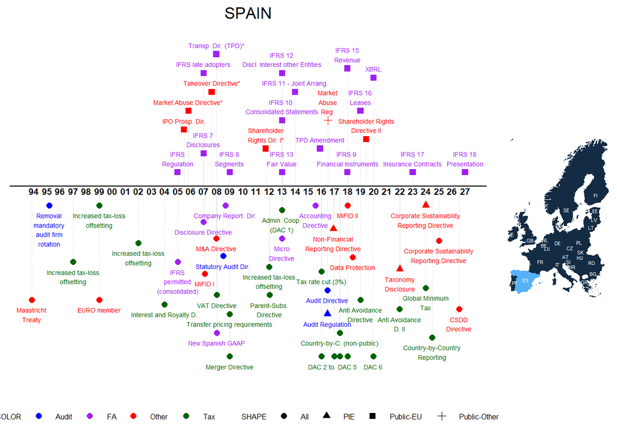

Notes: The graph depicts major regulatory changes that we identified via an extensive literature search, an online survey of mentioned authors, and other sources. Please note that the graph does not include all possible regulatory changes, e.g. minor revisions to local GAAP or tax rate changes below 3% are not included. The dates of EU Directives are based on the official transposition deadlines unless denoted with a *, in which case we included the entry-to-force date as identified in the literature. For more information, please go to [Labro and Pierk (2023)](http://www.eu-regulations.com/Labro_Pierk_2023.pdf). We kindly ask that you cite the paper if you use the information on this website in your research project. Do you have comments or see anything missing? Please email us!

## Regulations, Publications, Further Graphs

The tab ‘Regulations’ includes links to the regulations, gives short descriptions, and provides selective papers for further reading. If the regulation is a national transposition of an EU Directive, the link to the Directive is given. The tab ‘Number of Regulations’ shows graphically the number of regulations 8 years around the respective year (-4,-3,-2,-1,0,+1,+2,+3). The tab ‘Number of Categories” shows graphically the number of different categories 8 years around the respective year (-4,-3,-2,-1,0,+1,+2,+3). The tab ’Publications’ shows all publications that include the countries’ names and variations thereof in the title, abstract, or keywords. Similarly, the tab ‘SSRN’ shows papers of the SSRN Accouning Research Network that include the countries’ names and variations.

### Regulations

|  | Date | Milestones | Applies_to | Category | Description |
| --- | --- | --- | --- | --- | --- |
| 1 | 1993-11-01 | Maastricht Treaty | Public-EU | FA | Maastricht Treaty: Signed 'Treaty on European Union". |
| 2 | 1995-03-09 | Removal mandatory audit firm rotation | All Firms | Audit | Removal mandatory audit firm rotation: Mandatory audit firm rotation was implemented in 1988 for large firms, and abolished in 1995. See also: Carrera, Gómez‐Aguilar, Humphrey, and Ruiz‐Barbadillo 200… |
| 3 | 1997-01-01 | Increased tax-loss offsetting | All Firms | Tax | Increased tax-loss offsetting: Tax loss carryforwards was increased from 5 to 7 years. See also: Dreßler and Overesch 2013 |
| 4 | 1999-01-01 | Euro member | All Firms | FA | Euro member: Euro area member since 1 January 1999. |
| 5 | 1999-01-01 | Increased tax-loss offsetting | All Firms | Tax | Increased tax-loss offsetting: Tax loss carryforwards was increased from 7 to 10 years. See also: Dreßler and Overesch 2013 |
| 6 | 2002-01-01 | Increased tax-loss offsetting | All Firms | Tax | Increased tax-loss offsetting: Tax loss carryforwards was increased from 10 to 15 years. See also: Dreßler and Overesch 2013 |
| 7 | 2004-01-01 | Interest and Royalty D. | All Firms | Tax | Ley 62 de 30/12/2003, de medidas fiscales administrativas y de orden social. BOE n° 313 de 31/12/2003 p. 46874 /// Correccion de errores y errata de la Ley 62 de 30/12/2003, de medidas fiscales admini… |
| 8 | 2005-01-01 | IFRS Regulation | Public-EU | FA | Regulation 1606/2002: Firms listed on EU-regulated markets are required to use the International Financial Reporting Standards (IFRS) for their consolidated financial statements. Firms that use US GAA… |
| 9 | 2005-01-01 | IFRS permitted (consolidated) | All Firms | FA | IFRS permitted: IFRS is permitted for private firms (consolidated statements), and required for groups that include at least one public entity. See also: André 2017 |
| 10 | 2005-07-01 | IPO Prospectus Directive | Public-EU | Other | Real DECRETO LEY 5 /2005, de 11 de marzo, de reformas urgentes para el impulso a la productividad y para la mejora de la contratación pública /// Real Decreto 1310/2005, de 4 de noviembre, por el que … |

[output cut: 51 more lines]

### Number of Regulations

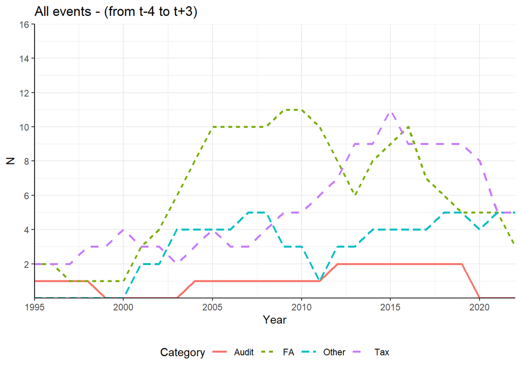

### Number of Categories

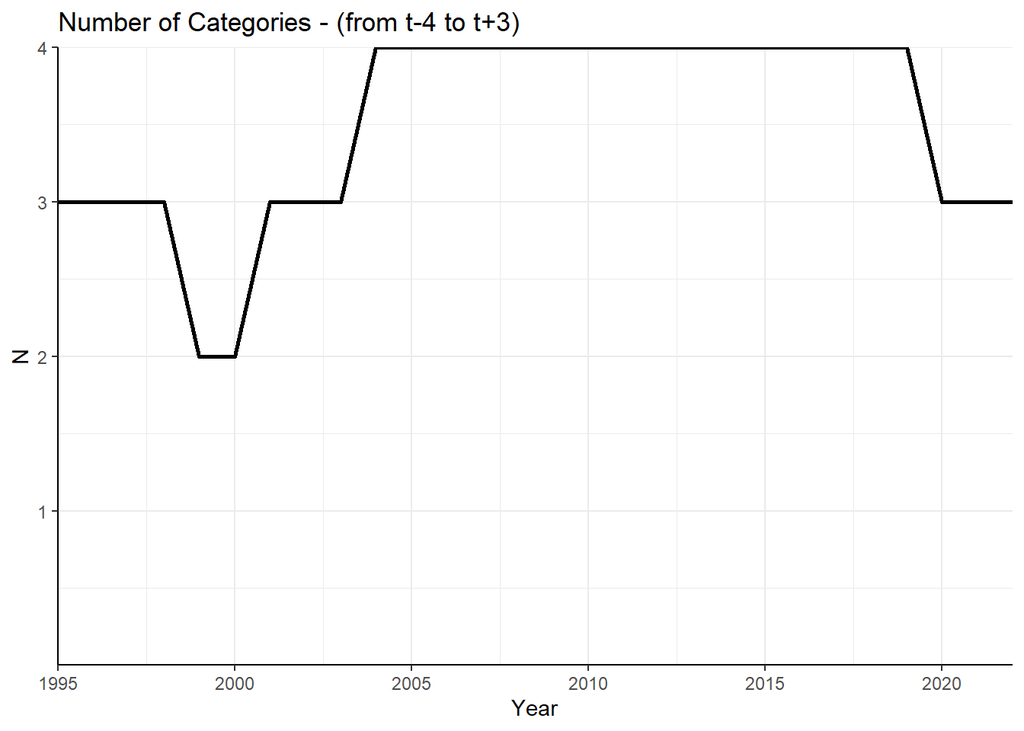

### Publications

|  | authors | title | year | journal |
| --- | --- | --- | --- | --- |
| 1 | Bonsón E., Lavorato D., Lamboglia R., Mancini D. | artificial intelligence activities and ethical approaches in leading listed companies in the european union | 2021 | International Journal of Accounting Information Systems |
| 2 | Osma B.G., Gill-de-Albornoz Noguer B., De Las Heras Cristóbal E., Rusanescu S. | opinion-shopping: firm versus partner-level evidence | 2021 | Accounting and Business Research |
| 3 | Ruiz-Lozano M., De Vicente-Lama M., Tirado-Valencia P., Cordobés-Madueño M. | the disclosure of the materiality process in sustainability reporting by spanish state-owned enterprises | 2021 | Accounting, Auditing and Accountability Journal |
| 4 | Sánchez-Ballesta J.P., Yagüe J. | social capital and earnings management in small and medium firms | 2021 | Accounting Forum |
| 5 | Yates D., Difrancesco R.M. | the view from the front line: shifting beneficiary accountability and interrelatedness in the time of a global pandemic | 2021 | Accounting, Auditing and Accountability Journal |
| 6 | Castillo-Merino D., Garcia-Blandon J., Martinez-Blasco M. | auditor independence, current and future nas fees and audit quality: were european regulators right? | 2020 | European Accounting Review |
| 7 | Garcia-Blandon J., Argiles J.M., Ravenda D. | on the relationship between audit tenure and fees paid to the audit firm and audit quality | 2020 | Accounting in Europe |
| 8 | Giner B., Mora A. | political interference in private entities' financial reporting and the public interest: evidence from the spanish financial crisis | 2020 | Accounting, Auditing and Accountability Journal |
| 9 | Guo B., Paraskevopoulou E., Santamaría Sánchez L. | disentangling the role of management control systems for product and process innovation in different contexts | 2019 | European Accounting Review |
| 10 | Santos-Cabalgante B., García Osma B., Romero Fúnez D. | accounting quality in railway companies during the nineteenth and twentieth centuries: the case of spanish norte and mza | 2019 | Accounting and Business Research |

[output cut: 103 more lines]

### SSRN

|  | authors | title | Posted | Revised |
| --- | --- | --- | --- | --- |
| 1 | Juan L. Gandía and David Huguet | combined effects of auditing and discretionary accruals on the cost of debt: evidence from spanish smes | 2021-10-19 |  |
| 2 | José Daniel Barquero Cabrero and Mercedes Cancelo | company philosophy and its reputation through an analysis of the merco ranking | 2021-08-20 |  |
| 3 | Vicente Pina, Patricia Bachiller and Lara Ripoll | analysis of the effectiveness of financial health regulation in spanish local governments | 2021-08-09 |  |
| 4 | Dov Fischer | tax ethics in the rashba’s responsa to saragossa | 2021-06-16 |  |
| 5 | Anastasios Elemes and Andrei Filip | financial reporting quality and private firms’ access to trade credit capital | 2021-04-26 |  |
| 6 | Nicolás Parra-Bolaños, William Alonso Londoño Monsalve, Claudia Estela Herrera Cárdenas, Juan Sebastián Benjumea-Garcés, Hernán Enrique Rueda Garcés, Diego Omar Guevara Torrecillas, Steeven Andrés Mor… | la investigación multidisciplinaria una mirada desde la educación, empresa, sociedad y tecnologías (multidisciplinary research from the perspective of education, business, society and technology) | 2021-04-23 |  |
| 7 | Alessia Patuelli and Jonida Carungu | a comparative study of the accounting research trends (1994–2014) between spain and italy | 2021-04-15 |  |
| 8 | Anne M. Garvey, Juan Manuel Pérez Salamero González, Manuel Ventura-Marco and Carlos Vidal-Meliá | from ‘table 29’ to the actuarial balance sheet: is it really that big a leap? | 2021-04-09 |  |
| 9 | Andrés Alonso and José Manuel Carbó | understanding the performance of machine learning models to predict credit default: a novel approach for supervisory evaluation | 2021-01-27 |  |
| 10 | Juan L. Gandía and David Huguet | audit fees and earnings management: differences based on the type of audit | 2020-12-30 | 2021-06-30 |

[output cut: 12 more lines]